# dsx RNA-seq analysis

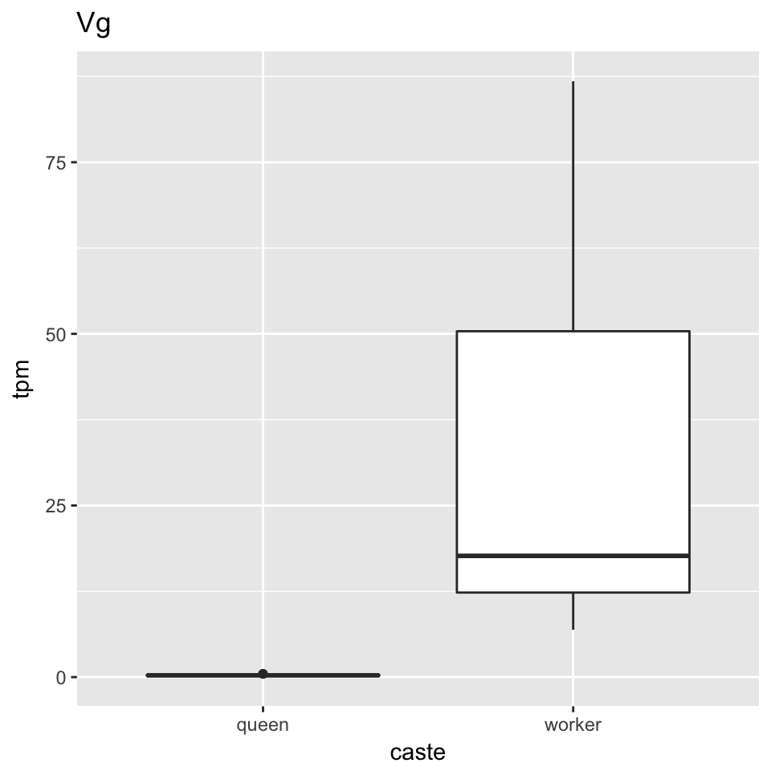

```r
data.frame(tpm = t(as.vector(heTPM %>% dplyr::filter(gene_id == "Vg") %>% dplyr::select(heFactors$sample))), caste = heFactors$caste) %>% ggplot(aes(caste,tpm))+geom_boxplot()+ggtitle("Vg")
```

```r
dsxIsoforms <- tibble(isoform_id = c("NM_001111255.1", "NM_001134935.1", "NM_001134936.1", "NR_024131.1" ,"XM_006560013.2"), description = c("M", "F2", "B", "RNA", "X1"))
heIsoforms <- read_csv("data/he_isoforms_counts.csv.gz", col_types = cols()) %>% filter(! grepl("ERCC", isoform_id))
heCdsIso <- DGEList( heIsoforms[, heFactors$sample], group = heFactors$caste)
heCdsIso <- calcNormFactors( heCdsIso)
heCdsIso <- estimateDisp( heCdsIso, design)
heCdsIso.tgw <- exactTest( heCdsIso , pair = c( "worker" , "queen" ) )
heCdsIso.tgw$table$isoform_id <- heIsoforms$isoform_id
kable(heCdsIso.tgw$table %>% filter(isoform_id %in% dsxIsoforms$isoform_id) %>% left_join(dsxIsoforms, by = "isoform_id"))
```

| logFC | logCPM | PValue | isoform_id | description |
| --- | --- | --- | --- | --- |
| -0.0263521 | 1.1356181 | 0.9297406 | NR_024131.1 | RNA |
| 0.1785177 | 3.5415856 | 0.5163568 | XM_006560013.2 | X1 |
| -0.8898835 | -1.6484068 | 0.5817895 | NM_001134936.1 | B |
| 1.2638771 | 0.1321281 | 0.1990717 | NM_001134935.1 | F2 |
| -1.3646990 | -2.4301461 | 0.5026855 | NM_001111255.1 | M |

As reported by the authors, *Dsx* is not differentially expressed by caste. However, even in our experiment, the difference is marginal, so we should look in some greater detail at other associated genes.

```r
heExpDat <- as.data.frame(t(heTPM[,-1]))
colnames(heExpDat) <- heTPM$gene_id
pickSoftThreshold(heExpDat, RsquaredCut = 0.8, networkType = "unsigned")$powerEstimate
```

```
##    Power SFT.R.sq  slope truncated.R.sq mean.k. median.k. max.k.
## 1      1    0.527  1.060          0.682  4020.0   4230.00   6890
## 2      2    0.472 -0.280          0.408  2000.0   1900.00   4650
## 3      3    0.709 -0.569          0.650  1210.0    977.00   3460
## 4      4    0.760 -0.688          0.723   807.0    546.00   2720
## 5      5    0.764 -0.774          0.750   576.0    323.00   2220
## 6      6    0.753 -0.845          0.762   430.0    198.00   1870
## 7      7    0.769 -0.894          0.801   332.0    126.00   1600
## 8      8    0.758 -0.941          0.813   263.0     82.70   1380
## 9      9    0.770 -0.972          0.838   212.0     56.00   1210
## 10    10    0.779 -1.010          0.857   173.0     38.80   1070
## 11    12    0.788 -1.070          0.887   121.0     20.30    856
## 12    14    0.789 -1.120          0.902    87.5     11.10    699
## 13    16    0.799 -1.160          0.920    65.3      6.59    580
## 14    18    0.807 -1.190          0.933    49.9      4.22    488
## 15    20    0.817 -1.220          0.943    38.8      2.63    416
```

```
## [1] 18
```

It is pretty close to what we have in the other network, and we’ll use the same power 12

```r
heNet <- blockwiseModules(heExpDat, power = 12,
TOMType = "unsigned", minModuleSize = 30,
reassignThreshold = 0, mergeCutHeight = 0.25,
numericLabels = TRUE, pamRespectsDendro = FALSE,
saveTOMs = FALSE,
verbose = 3, maxBlockSize = 15000)
saveRDS(heNet, "data/he_net.rds")
```

Do the *Dsx* containing modules overlap between studies

```r
heAlldegrees <- intramodularConnectivity.fromExpr(heExpDat, heNet$colors, power = 12)
```

```
##  softConnectivity: FYI: connecitivty of genes with less than 12 valid samples will be returned as NA.
##  ..calculating connectivities..
```

```r
heAlldegrees$gene_id <- colnames(heExpDat)
(heDsxModule <- heNet$colors[which(colnames(heExpDat) == "Dsx")])
```

```
## [1] 2
```

```r
heDsxModuleGenes <- colnames(heExpDat)[heNet$colors == heDsxModule]

bothDsx <- table(net$colors == DsxModule & heNet$colors == heDsxModule)[2]
heDsx <- table(heNet$colors == heDsxModule)[2]
ourDsx <- table(net$colors == DsxModule)[2]
phyper(bothDsx, ourDsx, table(net$colors == DsxModule)[1], heDsx, lower.tail = F)
```

```
##         TRUE
## 3.751621e-52
```

```r
sum(bothDsx)/sum(ourDsx)
```

```
## [1] 0.5056877
```

```r
heDsxModuleGenes <- descriptions %>% filter(gene_id %in% colnames(heExpDat)[heNet$colors == heDsxModule] ) %>% left_join(deHe.tgw$table, by = "gene_id") %>% left_join(heAlldegrees %>% dplyr::select(gene_id, kWithin), by="gene_id") %>% dplyr::select(gene = gene_id, description = description.x, logFC, kWithin, logCPM) %>% arrange(desc(logFC))
highligh <- which(heDsxModuleGenes$gene %in% colnames(heExpDat)[net$colors == DsxModule])
heDsxModuleGenes  %>% arrange(desc(kWithin)) %>% kable(format = "html", caption = "Genes in the Dsx-containing module from He et al. Higher values of logFC correspond to greater expression in queens Genes also found in the Dsx-responsive module from the RNAi experiment are highlighted in yellow") %>% row_spec(highligh, bold = T, background = "#FFFF00") %>% kable_styling(bootstrap_options = c("striped", "hover", "condensed", "responsive")) %>% scroll_box(height = "400px")
```

Genes in the Dsx-containing module from He et al. Higher values of logFC correspond to greater expression in queens Genes also found in the Dsx-responsive module from the RNAi experiment are highlighted in yellow

| gene | description | logFC | kWithin | logCPM |
| --- | --- | --- | --- | --- |
| LOC551446 | RNA-binding protein lark | 0.0759105 | 367.1710443 | 9.2662342 |
| LOC726544 | serine/threonine-protein phosphatase 4 regulatory subunit 1-like | -0.1651126 | 360.1741322 | 7.7175277 |
| LOC727008 | probable ATP-dependent RNA helicase DDX46 | 0.1750100 | 357.6742550 | 7.3478951 |
| LOC410398 | insulin-like growth factor 2 mRNA-binding protein 1 | -0.0307601 | 357.0088942 | 9.4372170 |
| LOC410585 | DE-cadherin | -0.0815361 | 352.2130477 | 6.3047862 |
| LOC408793 | histone acetyltransferase KAT7 | -0.0369484 | 346.0787472 | 6.1884381 |
| LOC724417 | uncharacterized protein CG43867 | 0.0687125 | 344.4485991 | 5.6834534 |
| LOC102656501 | zinc finger protein 2-like | 0.1548814 | 343.2475807 | 5.9556795 |
| LOC411234 | aryl hydrocarbon receptor nuclear translocator homolog | 0.0390675 | 339.7521012 | 5.9260672 |
| LOC410502 | transformation/transcription domain-associated protein | 0.2116009 | 338.1609437 | 6.4239126 |
| LOC726671 | uncharacterized LOC726671 | -0.0222037 | 337.9145952 | 4.1247768 |
| LOC725433 | uncharacterized LOC725433 | 0.0507481 | 336.8245768 | 6.7162238 |
| LOC409065 | TAR DNA-binding protein 43 | 0.0277555 | 336.7258371 | 7.4522753 |
| LOC100576404 | probable helicase with zinc finger domain | -0.1105016 | 335.6643772 | 6.9528521 |
| LOC409921 | zinc finger protein Elbow-like | -0.1995200 | 334.9183897 | 4.1847294 |
| LOC102654736 | zinc finger protein 239-like | -0.0022730 | 332.7989318 | 3.9882254 |
| LOC409242 | protein PRRC2C-like | 0.1466820 | 331.7052517 | 9.3822703 |
| LOC409961 | heterogeneous nuclear ribonucleoprotein 27C | 0.0602988 | 331.6479012 | 8.3797616 |
| LOC414025 | zinc finger protein Noc-like | -0.2279467 | 330.5436836 | 5.3805834 |
| LOC408372 | poly(rC)-binding protein 3 | 0.0431607 | 329.0802947 | 7.0986739 |
| LOC410775 | laminin subunit alpha-1 | -0.0459389 | 324.1372538 | 6.7968404 |
| LOC724242 | protein neuralized | -0.0249785 | 323.7974055 | 5.5840059 |
| LOC726280 | histone acetyltransferase p300-like | 0.1208942 | 322.1416705 | 7.6077927 |
| LOC551203 | E3 ubiquitin-protein ligase MYCBP2-like | -0.0080336 | 321.1630922 | 5.6781792 |
| LOC409158 | C-terminal-binding protein | -0.0597774 | 320.0745527 | 7.9299602 |
| LOC551071 | bromodomain adjacent to zinc finger domain protein 2B | -0.0072832 | 319.9032028 | 6.6667079 |
| LOC409711 | kazrin | -0.3225122 | 319.6642883 | 3.0602884 |
| LOC413024 | carboxyl-terminal PDZ ligand of neuronal nitric oxide synthase protein-like | -0.0625718 | 319.1813146 | 4.4423340 |
| LOC412997 | DDB1- and CUL4-associated factor 10 | 0.1246740 | 319.0958583 | 5.2555203 |
| LOC551973 | cleavage and polyadenylation specificity factor subunit CG7185 | 0.2538421 | 318.8810562 | 7.4743922 |

[output cut: 3889 more lines]

Yes, roughly half of the genes in the *Dsx*-responsive module form the RNAi experiment are found in the *Dsx*-containing module determined from larval gene expression.

Now, is the *Dsx*-containig module associated with caste-biased gene expression?

```r
# module membership vs logFC
cor.test(heAlldegrees$kWithin[net$colors == heDsxModule], deHe.tgw$table$logFC[net$colors == heDsxModule], method = "s")
```

```
##
##  Spearman's rank correlation rho
##
## data:  heAlldegrees$kWithin[net$colors == heDsxModule] and deHe.tgw$table$logFC[net$colors == heDsxModule]
## S = 569320000, p-value < 2.2e-16
## alternative hypothesis: true rho is not equal to 0
## sample estimates:
##       rho
## 0.2269898
```

```r
#logFC in experimental vs developmental modules
with(left_join(deHe.tgw$table[heNet$colors == heDsxModule,],de.tgw$table[net$colors == DsxModule,] %>% dplyr::select(gene_id, logFC), by = "gene_id") %>% na.omit(), cor.test(logFC.x, logFC.y, method="s"))
```

```
##
##  Spearman's rank correlation rho
##
## data:  logFC.x and logFC.y
## S = 21374000, p-value = 0.03243
## alternative hypothesis: true rho is not equal to 0
## sample estimates:
##         rho
## -0.09677078
```

This means that the *Dsx*-containing module is associated with queen-upregulated genes during development. The number of genes that overlap in the two modules is not very large, but their logFC are (negatively) correlated.

## Session info

```
##  setting  value
##  version  R version 3.4.1 (2017-06-30)
##  system   x86_64, darwin15.6.0
##  ui       X11
##  language (EN)
##  collate  en_US.UTF-8
##  tz       Australia/Sydney
##  date     2018-02-21
```

package

version

date

source

acepack

1.4.1

2016-10-29

CRAN (R 3.4.0)

annotate

1.54.0

2017-04-25

Bioconductor

AnnotationDbi

1.38.2

2017-07-27

Bioconductor

AnnotationForge

1.18.2

2017-09-02

Bioconductor

assertthat

0.2.0

2017-04-11

CRAN (R 3.4.0)

backports

1.1.2

2017-12-13

CRAN (R 3.4.3)

base

3.4.1

2017-07-07

local

base64enc

0.1-3

2015-07-28

CRAN (R 3.4.0)

bindr

0.1

2016-11-13

CRAN (R 3.4.0)

bindrcpp

0.2

2017-06-17

CRAN (R 3.4.0)

Biobase

2.36.2

2017-05-04

Bioconductor

BiocGenerics

0.22.1

2017-10-07

Bioconductor

bit

1.1-12

2014-04-09

CRAN (R 3.4.0)

bit64

0.9-7

2017-05-08

CRAN (R 3.4.0)

bitops

1.0-6

2013-08-17

CRAN (R 3.4.0)

blob

1.1.0

2017-06-17

CRAN (R 3.4.0)

broom

0.4.3

2017-11-20

CRAN (R 3.4.1)

Category

2.42.1

2017-06-24

Bioconductor

cellranger

1.1.0

2016-07-27

CRAN (R 3.4.0)

checkmate

1.8.5

2017-10-24

CRAN (R 3.4.2)

cli

1.0.0

2017-11-05

CRAN (R 3.4.2)

cluster

2.0.6

2017-03-10

CRAN (R 3.4.1)

codetools

0.2-15

2016-10-05

CRAN (R 3.4.1)

colorspace

1.3-2

2016-12-14

CRAN (R 3.4.0)

compiler

3.4.1

2017-07-07

local

crayon

1.3.4

2017-09-16

CRAN (R 3.4.1)

data.table

1.10.4-3

2017-10-27

CRAN (R 3.4.2)

datasets

3.4.1

2017-07-07

local

DBI

0.7

2017-06-18

CRAN (R 3.4.0)

DEoptimR

1.0-8

2016-11-19

CRAN (R 3.4.0)

devtools

1.13.4

2017-11-09

CRAN (R 3.4.2)

digest

0.6.15

2018-01-28

CRAN (R 3.4.3)

doParallel

1.0.11

2017-09-28

CRAN (R 3.4.2)

dplyr

0.7.4

2017-09-28

CRAN (R 3.4.2)

dynamicTreeCut

1.63-1

2016-03-11

CRAN (R 3.4.0)

edgeR

3.18.1

2017-05-06

Bioconductor

ellipse

0.4.1

2018-01-05

CRAN (R 3.4.3)

evaluate

0.10.1

2017-06-24

CRAN (R 3.4.1)

fastcluster

1.1.24

2017-08-21

CRAN (R 3.4.1)

fit.models

0.5-14

2017-04-06

CRAN (R 3.4.0)

forcats

0.2.0

2017-01-23

CRAN (R 3.4.0)

foreach

1.4.4

2017-12-12

CRAN (R 3.4.3)

foreign

0.8-69

2017-06-22

CRAN (R 3.4.1)

Formula

1.2-2

2017-07-10

CRAN (R 3.4.1)

genefilter

1.58.1

2017-05-06

Bioconductor

ggplot2

2.2.1

2016-12-30

CRAN (R 3.4.0)

ggsignif

0.4.0

2017-08-03

CRAN (R 3.4.1)

glue

1.2.0

2017-10-29

CRAN (R 3.4.2)

GO.db

3.4.1

2017-08-03

Bioconductor

GOstats

2.42.0

2017-04-25

Bioconductor

graph

1.54.0

2017-04-25

Bioconductor

graphics

3.4.1

2017-07-07

local

grDevices

3.4.1

2017-07-07

local

grid

3.4.1

2017-07-07

local

gridExtra

2.3

2017-09-09

CRAN (R 3.4.1)

GSEABase

1.38.2

2017-09-21

Bioconductor

gtable

0.2.0

2016-02-26

CRAN (R 3.4.0)

haven

1.1.1

2018-01-18

CRAN (R 3.4.3)

highr

0.6

2016-05-09

CRAN (R 3.4.0)

Hmisc

4.1-1

2018-01-03

CRAN (R 3.4.1)

hms

0.4.1

2018-01-24

CRAN (R 3.4.3)

htmlTable

1.11.2

2018-01-20

CRAN (R 3.4.3)

htmltools

0.3.6

2017-04-28

CRAN (R 3.4.0)

htmlwidgets

1.0

2018-01-20

CRAN (R 3.4.3)

httr

1.3.1

2017-08-20

CRAN (R 3.4.1)

igraph

1.1.2

2017-07-21

CRAN (R 3.4.1)

impute

1.50.1

2017-05-06

Bioconductor

IRanges

2.10.5

2017-10-08

Bioconductor

iterators

1.0.9

2017-12-12

CRAN (R 3.4.3)

jsonlite

1.5

2017-06-01

CRAN (R 3.4.0)

kableExtra

0.7.0

2018-01-15

CRAN (R 3.4.3)

knitr

1.19

2018-01-29

CRAN (R 3.4.3)

labeling

0.3

2014-08-23

CRAN (R 3.4.0)

lattice

0.20-35

2017-03-25

CRAN (R 3.4.1)

latticeExtra

0.6-28

2016-02-09

CRAN (R 3.4.0)

lazyeval

0.2.1

2017-10-29

CRAN (R 3.4.2)

limma

3.32.10

2017-10-13

Bioconductor

locfit

1.5-9.1

2013-04-20

CRAN (R 3.4.0)

lubridate

1.7.2

2018-02-06

CRAN (R 3.4.3)

magrittr

1.5

2014-11-22

CRAN (R 3.4.0)

MASS

7.3-48

2017-12-25

CRAN (R 3.4.3)

Matrix

1.2-12

2017-11-15

CRAN (R 3.4.2)

matrixStats

0.53.1

2018-02-11

cran (@0.53.1)

memoise

1.1.0

2017-04-21

CRAN (R 3.4.0)

methods

3.4.1

2017-07-07

local

mnormt

1.5-5

2016-10-15

CRAN (R 3.4.0)

modelr

0.1.1

2017-07-24

CRAN (R 3.4.1)

munsell

0.4.3

2016-02-13

CRAN (R 3.4.0)

mvtnorm

1.0-7

2018-01-25

CRAN (R 3.4.3)

networkD3

0.4

2017-03-18

CRAN (R 3.4.0)

nlme

3.1-131.1

2018-02-16

CRAN (R 3.4.3)

nnet

7.3-12

2016-02-02

CRAN (R 3.4.1)

parallel

3.4.1

2017-07-07

local

pcaPP

1.9-73

2018-01-14

CRAN (R 3.4.3)

pillar

1.1.0

2018-01-14

CRAN (R 3.4.3)

pkgconfig

2.0.1

2017-03-21

CRAN (R 3.4.0)

plyr

1.8.4

2016-06-08

CRAN (R 3.4.0)

preprocessCore

1.38.1

2017-05-06

Bioconductor

psych

1.7.8

2017-09-09

CRAN (R 3.4.1)

purrr

0.2.4

2017-10-18

CRAN (R 3.4.2)

qvalue

2.8.0

2017-04-25

Bioconductor

R6

2.2.2

2017-06-17

CRAN (R 3.4.0)

RBGL

1.52.0

2017-04-25

Bioconductor

RColorBrewer

1.1-2

2014-12-07

CRAN (R 3.4.0)

Rcpp

0.12.15

2018-01-20

CRAN (R 3.4.3)

RCurl

1.95-4.10

2018-01-04

CRAN (R 3.4.3)

readr

1.1.1

2017-05-16

CRAN (R 3.4.0)

readxl

1.0.0

2017-04-18

CRAN (R 3.4.0)

reshape2

1.4.3

2017-12-11

CRAN (R 3.4.3)

rlang

0.1.6

2017-12-21

CRAN (R 3.4.3)

rmarkdown

1.8

2017-11-17

CRAN (R 3.4.2)

robust

0.4-18

2017-04-27

CRAN (R 3.4.0)

robustbase

0.92-8

2017-11-01

CRAN (R 3.4.2)

rpart

4.1-12

2018-01-12

CRAN (R 3.4.3)

rprojroot

1.3-2

2018-01-03

CRAN (R 3.4.1)

rrcov

1.4-3

2016-09-06

CRAN (R 3.4.0)

RSQLite

2.0

2017-06-19

CRAN (R 3.4.1)

rstudioapi

0.7

2017-09-07

CRAN (R 3.4.1)

rvest

0.3.2

2016-06-17

CRAN (R 3.4.0)

S4Vectors

0.14.7

2017-10-08

Bioconductor

scales

0.5.0

2017-08-24

CRAN (R 3.4.1)

scatterD3

0.8.1

2016-12-13

CRAN (R 3.4.0)

sleuth

0.29.0

2018-02-19

Github (pachterlab/sleuth@8308dfd)

splines

3.4.1

2017-07-07

local

stats

3.4.1

2017-07-07

local

stats4

3.4.1

2017-07-07

local

stringi

1.1.6

2017-11-17

CRAN (R 3.4.2)

stringr

1.2.0

2017-02-18

CRAN (R 3.4.0)

survival

2.41-3

2017-04-04

CRAN (R 3.4.1)

tibble

1.4.2

2018-01-22

CRAN (R 3.4.3)

tidyr

0.8.0

2018-01-29

CRAN (R 3.4.3)

tidyselect

0.2.3

2017-11-06

CRAN (R 3.4.2)

tidyverse

1.2.1

2017-11-14

CRAN (R 3.4.2)

tools

3.4.1

2017-07-07

local

utils

3.4.1

2017-07-07

local

viridisLite

0.3.0

2018-02-01

CRAN (R 3.4.1)

WGCNA

1.62

2018-02-12

CRAN (R 3.4.1)

withr

2.1.1

2017-12-19

CRAN (R 3.4.3)

XML

3.98-1.9

2017-06-19

CRAN (R 3.4.1)

xml2

1.2.0

2018-01-24

CRAN (R 3.4.3)

xtable

1.8-2

2016-02-05

CRAN (R 3.4.0)

yaml

2.1.16

2017-12-12

CRAN (R 3.4.3)